# Stat 371 Homework #7. Due Sunday Oct. 25 11:59 pm

Henry Mendoza Rivera, UW-Madison, Department of Statistics.

# 1 Problem 1

If there is strong evidence that the median weight of his pumpkins from the jumbo patch is different from 16, then a farmer feels like he will need to give specific directions to his staff on how to sort and price them. He sampled 14 pumpkins from his jumbo patch and found weights of:

$$10.5, 11,12.6, 12.9, 14.8, 14.3, 16, 19.1, 10.2, 11.4, 9.3,21,30,35.$$

Run a test at level $\alpha = 0.05$ for this claim.

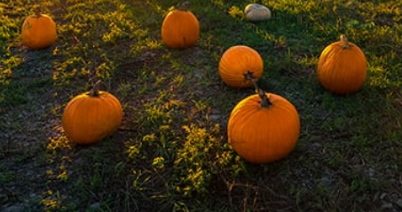

## 1.1 Solution

`Step 0`. Discard any data equal to $M_{0}=16$, reducing n accordingly

```r
weights<-c(10.5, 11,12.6, 12.9, 14.8, 14.3, 16, 19.1, 10.2, 11.4, 9.3,21,30,35)
weights==16
```

```
##  [1] FALSE FALSE FALSE FALSE FALSE FALSE  TRUE FALSE FALSE FALSE FALSE FALSE
## [13] FALSE FALSE
```

Since there is a value that is equal to 16, we delete it. Thus, the new data is

```r
weights1<-c(10.5, 11,12.6, 12.9, 14.8, 14.3,19.1, 10.2, 11.4, 9.3,21,30,35)
length(weights1)
```

```
## [1] 13
```

Now, we will analyze the data with 13 observations instead of 14.

`Step 1`. State null and alternative hypotheses and the significance level

1. `Claim`: “The median weight of his pumpkins from the jumbo patch is different from 16.”
2. The random variable $X$ involved in the claim is *The weight of the pumpkins*
3. The parameter of interest related to the variable $X$ is *the population median* $M$.
4. The claim in symbolic form is $M\ne 16$ (the median is significantly `different from 16`)
5. The claim in symbolic form that must be `opposite` to the original claim is $M= 16$
6. The null hypothesis is $H_0:M= 16\; \textrm{pounds}$, and the alternative hypothesis is $H_A: M\ne 16; \textrm{pounds}$.

## 1.2 Step 2. Describe the data

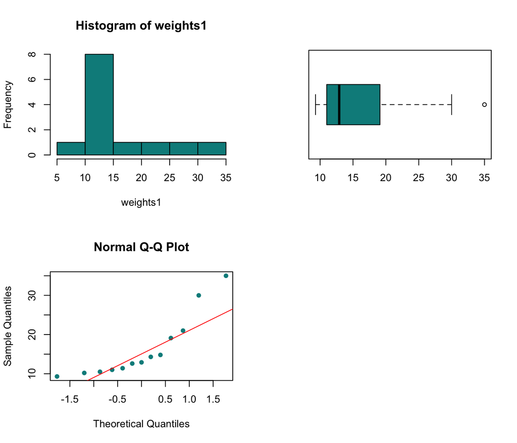

```r
par(mfrow=c(2,2))
hist(weights1,col="darkcyan")
boxplot(weights1,horizontal = TRUE,col="darkcyan")
qqnorm(weights1,col="darkcyan",pch=16)
qqline(weights1,col="red")
```

- The histogram looks Right-skewed. Since we only have n= 13, the `Central Limit Theorem is risky`, and in any event `our question is really about medians`.

## 1.3 Step 3. Check assumptions

- Is the sample a simple random sample?

Yes.

- Is the sample small?

Yes.

- Is the sample asymmetric?

Yes.

## 1.4 Step 4. Perform the appropriated test statistic and take the decision

- Under the null hypothesis, $B\sim Bin(13, 0.5)$.
- Calculate the test statistic.

```r
b=sum(weights1>16) # count the number of values in the data vector greater or equal that 16
b
```

```
## [1] 4
```

Our `observed test statistic` is $b=4$

`p-value Method`

We compute the test statistic with a binomial, $B\sim \text{Bin}(13, 0.5)$.

In this situation we would compute $P(B \ge b) = P(B \ge 4)$ and $P(B \le b) = P(B \le 4)$ and take twice the smaller of these two values as the p-value.

- $P(B \ge b) = P(B \ge 4)$

```r
p.value1=1-pbinom(3, size=13, prob = 0.5)
p.value1
```

```
## [1] 0.9538574
```

- $P(B \le b) = P(B \le 4)$

```r
p.value2=pbinom(4, size=13, prob = 0.5)
p.value2
```

```
## [1] 0.1334229
```

In this case, $0.1334229$ is smaller, so $2*0.1334229 =0.2668457$ is the p-value.

- We can obtain the same results as above using the `binom.test()` function in R

```r
binom.test(x=4, n=13, p = 0.5, alternative =  "two.sided", conf.level = 0.95)
```

```
##
##  Exact binomial test
##
## data:  4 and 13
## number of successes = 4, number of trials = 13, p-value = 0.2668
## alternative hypothesis: true probability of success is not equal to 0.5
## 95 percent confidence interval:
##  0.09092039 0.61426166
## sample estimates:
## probability of success
##              0.3076923
```

Where

- `x=4` is the observed value b of the statistics $B\sim \textrm{Binomial}(n=13,p=0.5)$ under the null hypothesis.
- `n=13` is the sample size after we delete the sample value equal to the assumed value under the null hypothesis.
- `p = 0.5` is a fixed value since we are dealing with a statistics $B\sim \textrm{Binomial}(n=13,p=0.5)$.
- `alternative = "two.sided"`. It comes from the fact that the alternative hypothesis is $H_A: M\ne 16; \textrm{pounds}$.
- `conf.level = 0.95` is the significant level is $\alpha=0.05$

## 1.5 Step 5. State the conclusion and interpret the decision

There is no strong evidence that the pumpkins’ median weight from the jumbo patch is different from 16. Then, the farmer does not need to give his staff specific directions on how to sort and price them.

# 2 Problem 2

Most penguin species are not sexually dimorphic, which means they lack obvious outward body characteristics that indicate sex. Observation of behavior or a blood test can determine Penguin sex. A penguin researcher is interested in estimating the proportion of females in a large penguin population. She takes a random sample of $n = 20$ penguins and determines the sex of each one using a blood test. She finds 12 males and 8 females. Let $\pi$ be the proportion of females in the population. Are the data strong evidence the population proportion of females is different from 63%? Run a test at level $\alpha = .05$ to find out. Follow the steps given in the lecture.

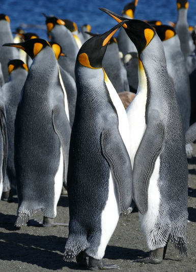

## 2.1 Step 1. State null and alternative hypotheses and the significance level

1. `Claim`: “Are the data strong evidence the population proportion of females penguins is different from 63%?.”
2. The random variable $X$ involved in the claim is: Number of females penguins is different from 63%.
3. The parameter of interest related to the variable $X$ is the population proportion of $\pi$ of female penguins.
4. The claim in symbolic form is: $\ne 0.63$ (the proportion of females penguins is different from 63%)
5. The claim in symbolic form that must be opposite to the original claim is: $\pi=0.63$
6. The null hypothesis is $H_0:\pi=0.63$, and the alternative hypothesis is $H_A: \ne 0.63$.
- Null and alternative hypotheses

$$\bbox[#ffcc99,20px,border:10px ligth red]
{
H_{0}: \pi=0.63 \;\;\;H_{A}: \pi \ne 0.63
}$$

## 2.2 Describe the variables

Since she finds 12 males and 8 females, females’ estimated proportion is $p=40$. That is $40\%$ of the penguins in the sample are females.

## 2.3 Step 3. Check assumptions

- Is the sample a simple random sample?

Yes.

- Do the conditions for a binomial random variable met?
  1. The number of observations (penguins) $n=20$ is fixed.
  2. The $n=20$ observations are independent.
  3. Each observation (penguins) has two possible outcomes: success (female) and failure (male).
  4. The probability of success on any trial is the same and unknown $\pi$.
  5. Then X= Number of females has a binomial distribution with parameters $n=20$ and $\pi$, abbreviated by

$$X\sim Bin(n=20,\pi)$$

- Is the Sample size large enough?

since $0.63(20) =12.6 \geq 5$ (the value 0.63 comes from the claim) and $0.37(20) = 7.4\geq 5$, we should be able to `use the Central Limit Theorem`.